# Sample Solar manipualtion

Jack Murray

2/12/2022

## #library

```r
library(tidyverse)
library(lubridate)
library(GGally)
```

## #Data read in

From Combined Solar Data

```r
data_files <- list.files("C:/Users/jackm/Desktop/Data Science/Project/Renewable_Power_Statistical_Model/TIDY_SOLAR_DATA")

for(i in 1:length(data_files))
{
  assign(
    paste0("data", i),
    read.csv(paste0("C:/Users/jackm/Desktop/Data Science/Project/Renewable_Power_Statistical_Model/TIDY_SOLAR_DATA/",data_files[i])))
}
```

Create 1 large data frame

```r
#all_solar_data <- data1

#for (j in 1:length(data_files))
#{
 # tempdata <- eval(parse(text = paste0("data",i)))
  all_solar_data <- rbind(data1,data2,data3,data4,data5,data6,data7,data8,data9,data10)
#}
```

## #Data Explaination

GHI –> Global horizontal irradiance *location influenced measure of solar radiation* GHI = DHI + DNI X cos (z) where z is the solar zenith angle *good measurements for solar panel production

DNI –> Direct normal irradiance *measure of the amount of radiation coming in the direction of the sun* effected by the cloud cover and particles in the atmosphere

DHI –> Diffuse horizontal irradiance *amount of radiation deflected by the atmosphere* large values indicate cloud cover and less radiation reaching the ground

## #Average Radiation Per Day

```r
Daily_Solar <- all_solar_data %>%
  group_by(Locations,DATE) %>%
  summarise(daily_DHI = mean(DHI.num),
            daily_DNI = mean(DNI.num),
            daily_GHI = mean(GHI.num),
            daily_Cloud = mean(CloudType.num),
            daily_Wind = mean(WindSpeed.num),
            daily_Cloud = mean(CloudType.num))
 head(Daily_Solar,10)
```

```
## # A tibble: 10 x 7
## # Groups:   Locations [1]
##    Locations DATE       daily_DHI daily_DNI daily_GHI daily_Cloud daily_Wind
##        <int> <chr>          <dbl>     <dbl>     <dbl>       <dbl>      <dbl>
##  1   1021900 1998-01-01      25.1   222.        101.         2.31       9.23
##  2   1021900 1998-01-02      30.8   189.         91.5        2.92       8.20
##  3   1021900 1998-01-03      17.9     0.146      18.0        4.5        7.77
##  4   1021900 1998-01-04      24.1     1.33       24.5        5.12       2.86
##  5   1021900 1998-01-05      43      36.2        56.3        6.10       4.93
##  6   1021900 1998-01-06      40.1    26.4        49.7        5.56       2.81
##  7   1021900 1998-01-07      19.4     0          19.4        6.17       3.99
##  8   1021900 1998-01-08      23.5     4.67       23.9        4.40       4.07
##  9   1021900 1998-01-09      36.3    84.3        68.1        2.83       5.78
## 10   1021900 1998-01-10      23.1   227.        102.         2.29       7.71
```

graphs

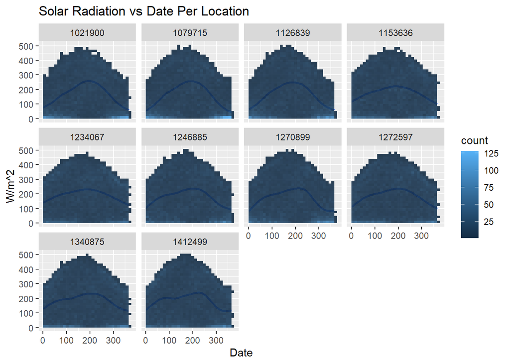

```r
plotdate_rad <- Daily_Solar %>%
  pivot_longer(cols = c(daily_DHI,daily_DNI,daily_GHI,daily_Wind),
               names_to = "Data type")

plotdate_rad %>%
  filter(`Data type` == c("daily_DNI"))%>%
  ggplot(aes(yday(DATE),value))+
  geom_smooth(se = FALSE)+
  geom_bin_2d(alpha=.9)+
  facet_wrap(vars(Locations))+
  labs(x = "Date",
       y = "W/m^2",
       title = "Solar Radiation vs Date Per Location")
```

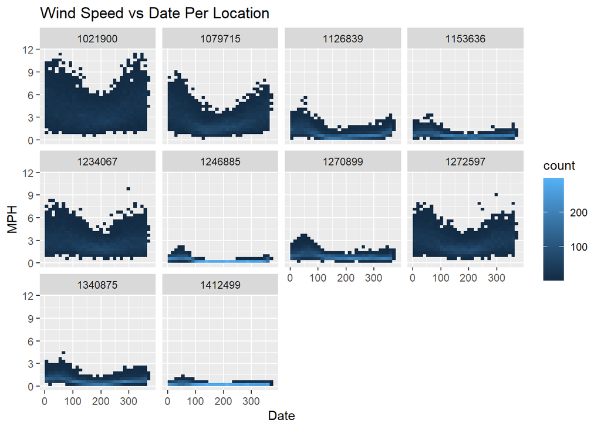

```r
plotdate_rad %>%
  filter(`Data type` == c("daily_Wind"))%>%
  ggplot(aes(yday(DATE),value))+
  #geom_point()+
  geom_bin_2d()+
  facet_wrap(vars(Locations))+
  labs(x = "Date",
       y = "MPH",
       title = "Wind Speed vs Date Per Location")
```

Time of the year dramatically effects the the amount of solar radiation and wind speed. In the summer, more direct rays from the sun and less cloud cover lead to universal increases in solar radiation. Also, their is a lot more variation in solar radiation in the summer too. Wind is the opposite, summer months have the lowest wind speeds and the least variation.

The in the winter is cloudier, therefore, more diffusion leads to larger percentage of solar radiation lose in the winter. Decreasing variation as well. Moreover, locations that experience higher wind speeds see a massive increase in average speed and variation in the winter. location with less wind see a reduced increase in winter.

## # Distribution of Wind speed per location

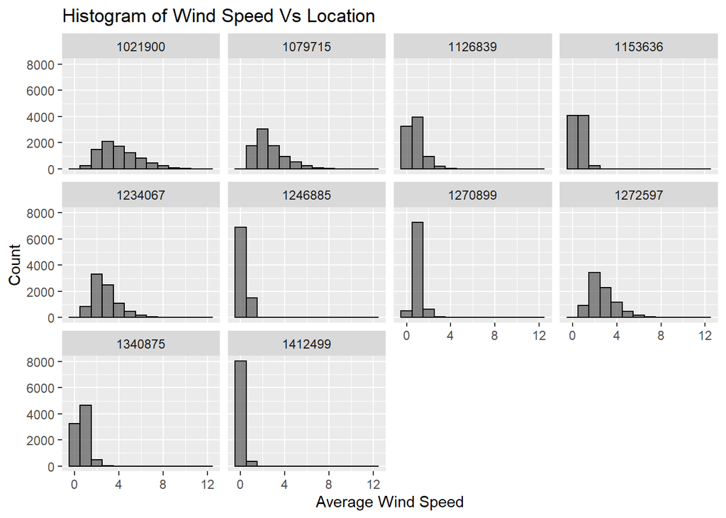

```r
plotLocation_wind <- Daily_Solar %>%
  select(Locations,daily_Wind)

plotLocation_wind %>%
  ggplot(aes(daily_Wind))+
  geom_histogram(binwidth = 1, color = "Black", alpha = .7)+
  facet_wrap(vars(Locations))+
  labs(x = "Average Wind Speed",
       y = "Count",
       title = "Histogram of Wind Speed Vs Location")
```

Wind speed is highly influenced by location, even in regionally there are dramatic differences. Some locations have less than 2 mph of wind on the majority of days, where as some experience a constant average wind of above 2 or 4 mph.

## #Average RAdtiation per month

```r
monthly <- Daily_Solar %>%
  mutate(mon = month(DATE),
         yr = year(DATE))%>%
  group_by(Locations,yr,mon)%>%
  summarise(mon_DHI = mean(daily_DHI),
            mon_DNI = mean(daily_DNI),
            mon_GHI = mean(daily_GHI))
head(monthly,6)
```

```
## # A tibble: 6 x 6
## # Groups:   Locations, yr [1]
##   Locations    yr   mon mon_DHI mon_DNI mon_GHI
##       <int> <dbl> <dbl>   <dbl>   <dbl>   <dbl>
## 1   1021900  1998     1    34.5    78.3    62.7
## 2   1021900  1998     2    49.4    97.0    90.9
## 3   1021900  1998     3    69.4   147.    151.
## 4   1021900  1998     4    82.7   206.    212.
## 5   1021900  1998     5   102.    237.    263.
## 6   1021900  1998     6   113.    231.    271.
```

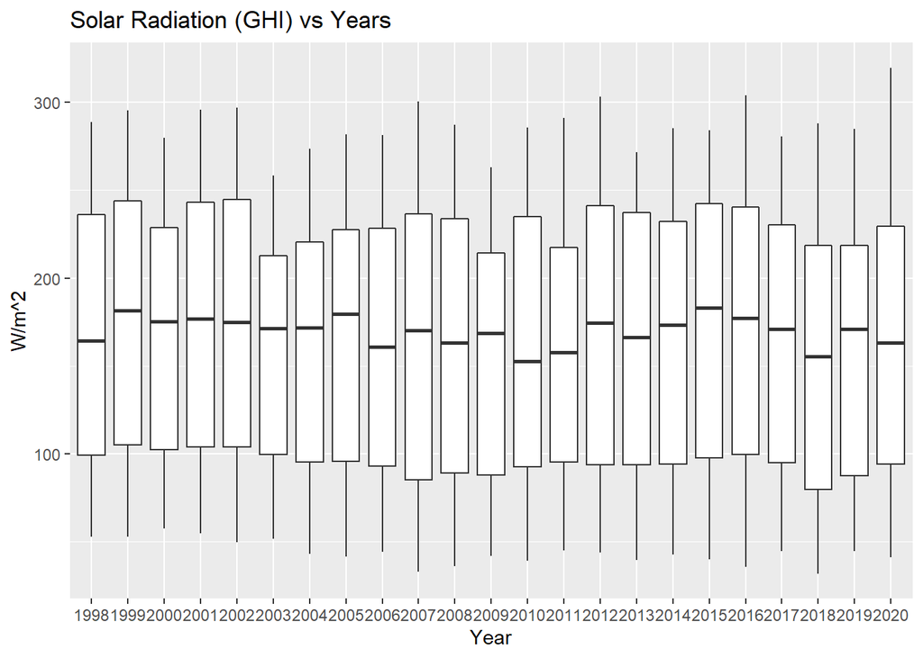

```r
plotmonth <- monthly %>%
  select(-mon_DHI)%>%
  pivot_longer(cols = c(mon_GHI,mon_DNI),
               names_to = "Radiation type")
plotmonth %>%
  filter(`Radiation type` == "mon_GHI") %>%
  ggplot(aes(as.character(yr),value))+
  geom_boxplot()+
  #facet_grid(cols = vars(value))+
  labs(x = "Year",
       y = "W/m^2",
       title = "Solar Radiation (GHI) vs Years")
```

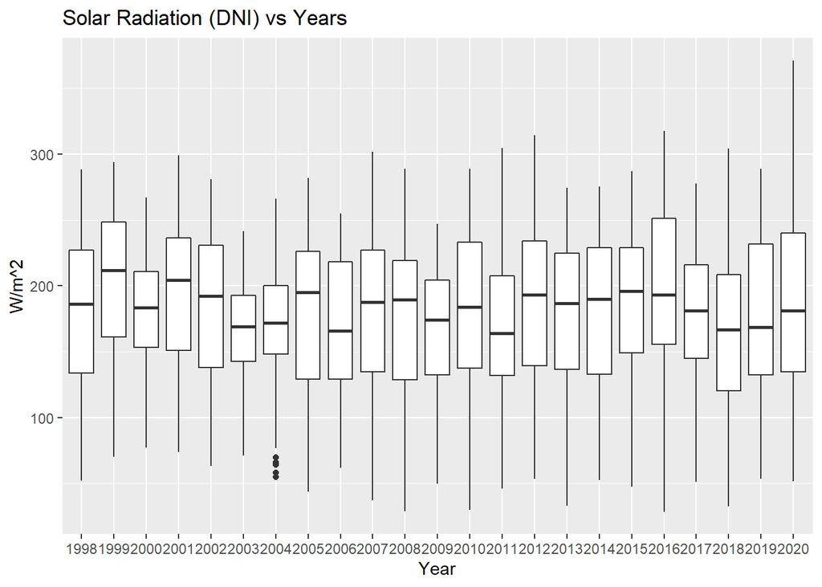

```r
plotmonth %>%
  filter(`Radiation type` == "mon_DNI") %>%
  ggplot(aes(as.character(yr),value))+
  geom_boxplot()+
  #facet_grid(cols = vars(value))+
  labs(x = "Year",
       y = "W/m^2",
       title = "Solar Radiation (DNI) vs Years")
```

Examines the effect time has had on the average solar radiation experienced. In the past 2 decades there has been little increase nor decrease in solar energy received. However, the median solar radiation expediences a sinusoidal pattern with a multiple year periods.

```r
#plotdate %>%
#  filter(`Radiation type`=="daily_GHI") %>%
#  ggplot(aes(value))+
#  geom_histogram(binwidth = 40, alpha =.4, color = "blue", fill = "blue")+
#  labs(x = "W/m2",
#       title = "Histogram of Daily Average Radiation")
```

## # Longitute and Latitiute Vs Wind and Solar

```r
lat_long_rad_wind <- all_solar_data %>%
  mutate(lat_long = paste0(Latitude,":",Longitude)) %>%
  group_by(lat_long) %>%
  summarise(meanGHI = mean(GHI.num),
            sdGHI = sd(GHI.num),
            meanWind = mean(WindSpeed.num),
            sdWind = sd(WindSpeed.num)) %>%
  mutate(Lat = as.numeric(substr(lat_long,1,5)),
         Long = as.numeric(substr(lat_long,7,11)))%>%
  select(-lat_long)
```

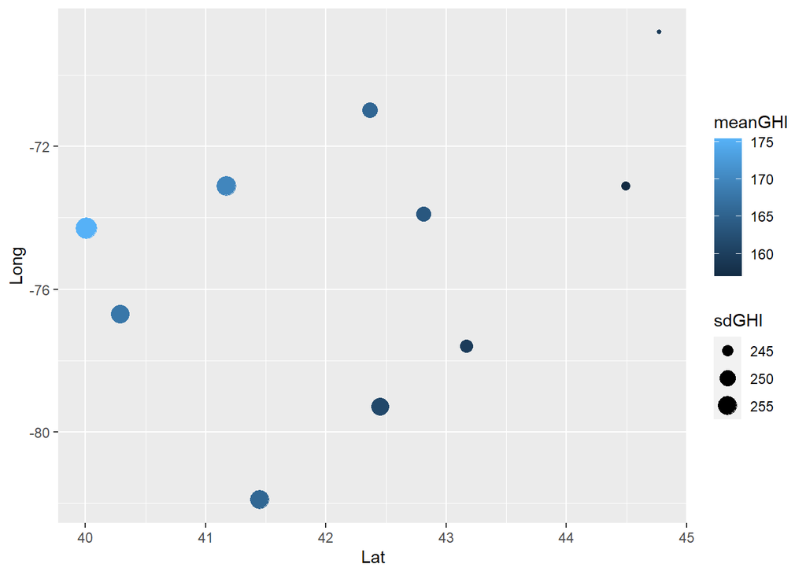

```r
lat_long_rad_wind %>%
  ggplot(aes(Lat,Long, color = meanGHI, size = sdGHI))+
    geom_point()
```

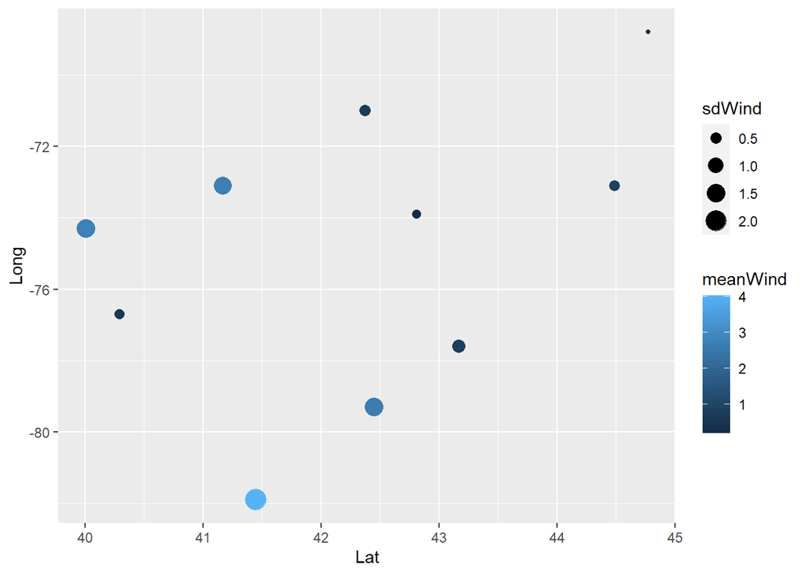

```r
lat_long_rad_wind %>%
  ggplot(aes(Lat,Long, color = meanWind, size = sdWind))+
    geom_point()
```

## # Wind Speed and Solar Radiation Vs Cloudcover

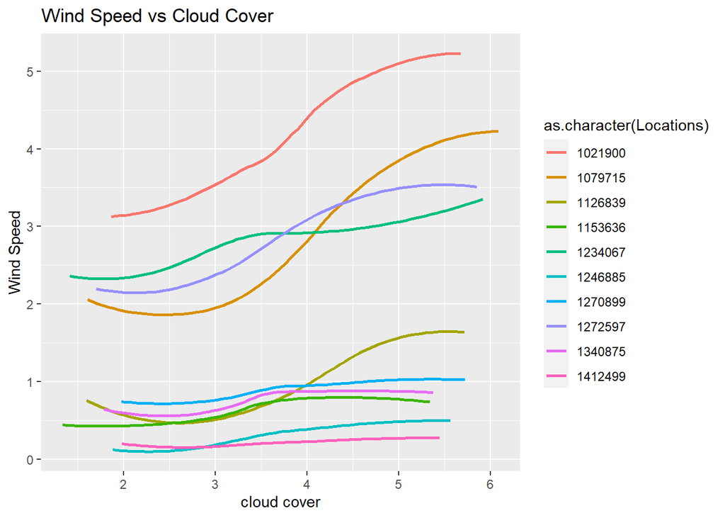

```r
dailycloud <- Daily_Solar %>%
  mutate(mon = month(DATE),
         yr = year(DATE))%>%
  group_by(Locations,mon,yr)%>%
  summarise(mon.wind = mean(daily_Wind),
            mon.GHI = mean(daily_GHI),
            mon.cloud = mean(daily_Cloud))
dailycloud%>%
  ggplot(aes(x = mon.cloud, y=mon.wind, color = as.character(Locations)))+
    geom_smooth(se = FALSE)+
    labs(x = "cloud cover", y = "Wind Speed", title = "Wind Speed vs Cloud Cover")
```

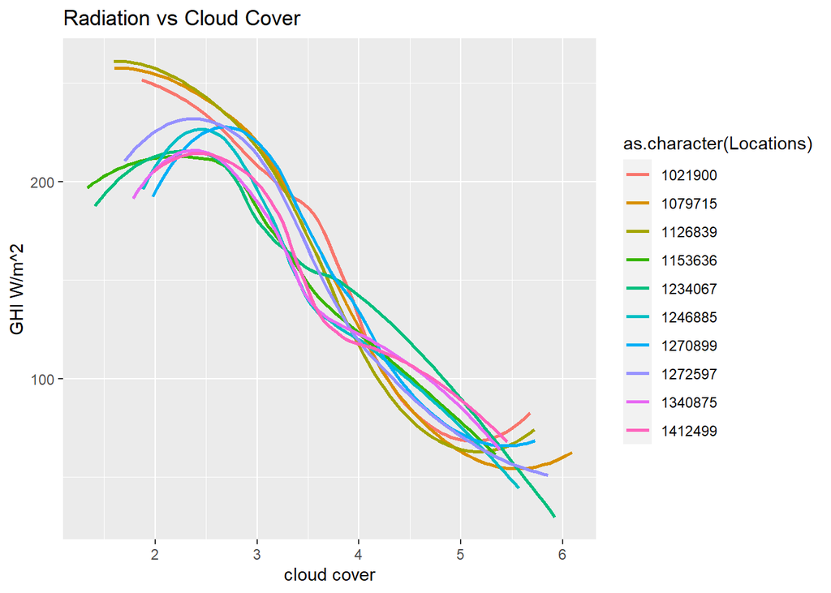

```r
dailycloud%>%
  ggplot(aes(x = mon.cloud, y=mon.GHI, color = as.character(Locations)))+
    geom_smooth(se = FALSE)+
    labs(x = "cloud cover", y = "GHI W/m^2", title = "Radiation vs Cloud Cover")
```

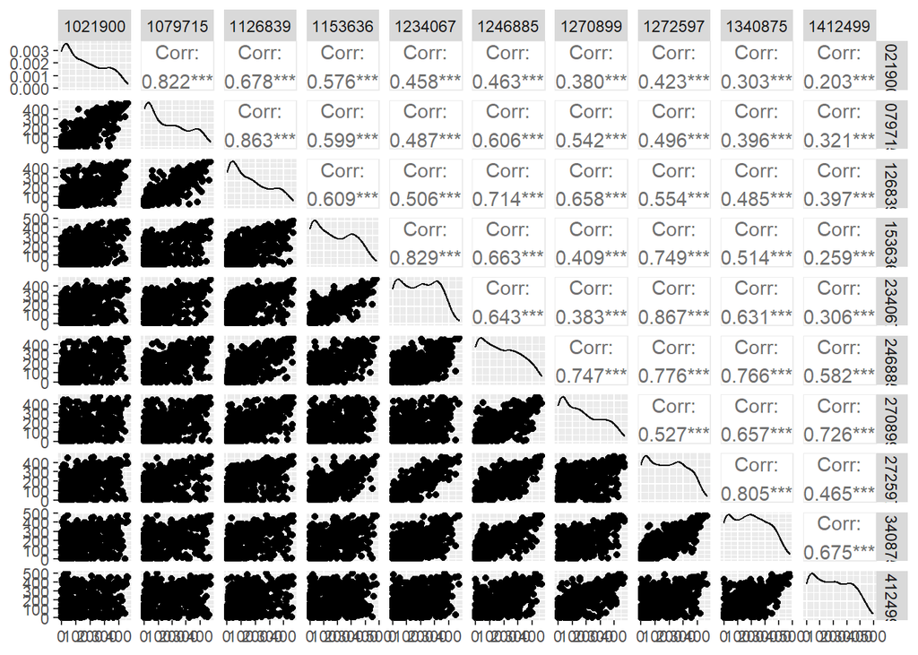

```r
locationCOL_solar <- Daily_Solar %>%
  select(DATE,daily_DNI,Locations)%>%
  pivot_wider(names_from = Locations,
              values_from = daily_DNI)%>%
  select(-DATE)%>%
  slice_sample(n = 420)

ggpairs(locationCOL_solar)
```

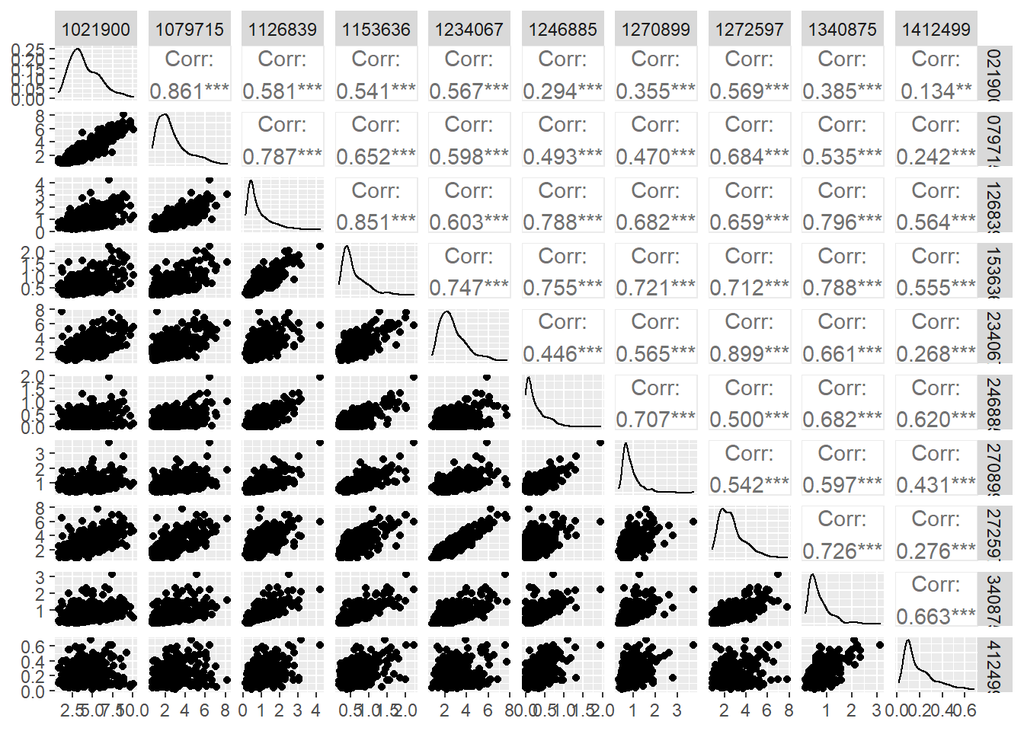

```r
locationCOL_wind <- Daily_Solar %>%
  select(DATE,daily_Wind,Locations)%>%
  pivot_wider(names_from = Locations,
              values_from = daily_Wind)%>%
  select(-DATE)%>%
  slice_sample(n = 420)

ggpairs(locationCOL_wind)
```

Similarly to the solar radiation pairs plot, location influences the wind speed. Also some locations are highly influenced by anther’s wind speed. For example, if the wind is low in 1234067, it will likely also be low in 1272597. The opposite is true of some locations as well, like 1412499 and 1021900 are barely influenced by each other at all.